# IBM Applied Data Science Capstone

# Where to Open LA's Next Artisanal Coffee Shop?

## Introduction / Executive Summary:

According to [Statista](https://www.statista.com/statistics/306896/cities-with-the-largest-number-of-starbucks-stores-us/), Los Angeles was ranked only 5th, in the US, in terms of having the largest number of Starbucks Coffeehouses, trailing cities like New York and Chicago. There are numerous possible explanations as to why, however the rise of the craft coffee movement is most certainly one of them. A growing awareness of concerns surrounding ESG (Environmental, Social and Corporate Governance), sustainability and sourcing has converted directly into consumers' daily purchasing habits.

Artisanal Coffee shops like "Upside Down" in Westwood have taken these concerns into account by sourcing their coffee from global producers with sustainable and ethical production practices. Despite higher costs, consumer demand has remained remarkably resilient as many consumers feel sustainable sourcing justifies the expensive cost.

LA has long been a trendsetter in terms of embracing fringe industries that since become mainstream, and artisanal coffee shops are no exception. Prospective entrepreneurs and investors alike are constantly scouring new opportunities to build profitable businesses in the right locations, but how exactly are these decisions made and what kind of data is used to inform these decisions?

In this report, we will scrape publicly available real-world data, and perform any required tidying before integrating it with geocoding services and the FourSquare API. Our analysis will be driven by visualizations including barplots and heatmaps, as well as statistical metrics such as correlation and averages to better refine our understanding and make predictions. K-means clustering will then be applied to FourSquare venues in LA neighborhoods to determine where best to open LA's next artisanal coffee shop.

## Data Sources:

In the following report, we will analyze data from the following sources to determine where best to open Los Angeles's next craft coffee shop:

1.) The [Foursquare API](https://developer.foursquare.com/) in order to locate and list different venues such as cafes, restaurants, shops and other services in order to better refine prospective neighborhoods.

2.) The GeoPy Nominatim Libary in order to locate the coordinates of all venues and neighborhoods.

1.) The [Foursquare API](https://developer.foursquare.com/) in order to locate and list different venues such as cafes, restaurants, shops and other services in order to better refine prospective neighborhoods. It will also be the source of venue-based features in our dataframe including "Venues" and "Venue Category."

2.) The GeoPy Nominatim Libary in order to locate the coordinates of all venues and neighborhoods. It will provide the "Latitude" and "Longitude" features in our dataframe.

3.) The Wikipedia Entry for the [List of districts and neighborhoods in Los Angeles](https://en.wikipedia.org/wiki/List_of_districts_and_neighborhoods_in_Los_Angeles) will provide the data for our "Neighborhood" feature.

4.) Average Monthly Rental Data scraped from the rental platform [RENTCafe](https://www.rentcafe.com/average-rent-market-trends/us/ca/los-angeles/), a US-based rental listing service for landlords and tenants. It maintains up-to-date listings of apartments for rent as well as data to determine the average cost of certain districts and neighborhoods. It will provide our values for the "Average Rent" feature in our dataframe.

## Methodology:

We will begin by installing or loading any required libaries or packages and detail their purposes.

In order to determine ideal locations for new high-end coffee shops, we will first scrape the Wikipedia HTML data for LA neighborhoods and clean any NAs or correct any strings (such as duplicates) that require tidying.

The GeoPy Nominatim Geolocator library will then be used to find the coordinates of LA and its neighborhoods. It will then be applied in conjunction with the Folium library to map out our data visually.

Next, the data will be fed through the FourSquare API from where we can begin our exploratory data analysis (EDA) by creating visualizations including scatterplots and treemaps to better convey correlations between the variables.

Our EDA will parse and collate neighborhood venue data in order to create visual rankings and potential predictions about neighborhoods that are likely to welcome a new artisanal coffee shop.

The average LA Monthly Rental Data from RENTCafe will then be scraped and joined with our main dataframe to determine whether any correlation between the number of coffee venues and the average monthly rental price exists.

After completing our EDA and establishing a better understanding of the data, we will apply the popular K-Means Clustering machine-learning algorithm to the dataset to define a range of desirable clusters from which we can base our preliminary recommendations.

## Libraries and Data Load:

### Import or Install the Required Libaries

```python
!pip install beautifulsoup4
```

```
     |████████████████████████████████| 102kB 22.9MB/s ta 0:00:01
```

```python
!pip install geopy
```

```
     |████████████████████████████████| 122kB 25.0MB/s eta 0:00:01
```

```python
!pip install squarify
```

```python
# Core libraries
import pandas as pd # to convert and clean raw data
from pandas.io.json import json_normalize # for normalizing tabular data
import numpy as np # for manipulating data with mathematical functions & statistical formulas

# JSON
import json # library to read, parse, & process JSON objects

# Visualization libraries
import matplotlib # converts tabular data into graphs & other visualizations
import matplotlib.colors as colors # color support for matplotlib
import matplotlib.cm as cm # additional color support
import folium # interactive mapping library
import seaborn as sns # statistical plotting libary
import matplotlib.pyplot as plt # matplotlib visuals
import squarify # for treemaps
from folium.plugins import HeatMap # for heatmaps

# Web-scraping
import requests # an http library for loading data
import lxml # for data conversion
from bs4 import BeautifulSoup # extracts & parses data from html & xml files
import re # library for regex

# Location data
from geopy.geocoders import Nominatim # used to find specific geographic locations

# Machine learning
from sklearn.cluster import KMeans # machine-learning classification algorithm
```

## Load and Scrape Neighborhood Data

```python
# Scrape and parse data from Wikipedia with requests and BeautifulSoup
url = requests.get('https://en.wikipedia.org/wiki/List_of_districts_and_neighborhoods_in_Los_Angeles').text
soup = BeautifulSoup(url, 'lxml')
```

### Create and Tidy the Table

```python
# After inspecting the html on Wikipedia, it's apparent we can simply scrape the first 4 'ul' elements
list = soup.find_all('ul')[1:5]
```

```python
# Next, we must extract the li elements from the ul elements by calling a simple function and populating "lis"
lis = []
for ul in list:
    for li in ul.findAll('li'):
          lis.append(li)
```

Calling the nrow function len confirms there are 201 potential neighborhoods, but we must inspect the list carefully to confirm whether this is true.

```python
len(lis)
```

```
201
```

Now we create "temp_list" to populate a new table with the li elements from "lis"

```python
temp_list = []

for i in range(0, len(lis)):
    temp_list.append(lis[i].text.strip())
```

```python
# Using pandas, we can now we can create the intial dataframe and title the column
df = pd.DataFrame(temp_list)
df.columns = ['Neighborhood']
```

Let's now inspect the df to determine any further potential required changes.

```python
df.head()
```

|  | Neighborhood |
| --- | --- |
| 0 | Angelino Heights[1] |
| 1 | Angeles Mesa[2] |
| 2 | Angelus Vista[2] |
| 3 | Arleta[3][1] |
| 4 | Arlington Heights[3] |

First, we notice the df is conveniently sorted alphabetically and that there are unnecessary square brackets to remove.

```python
# Let's begin tidying the df
df['Neighborhood'] = df.Neighborhood.str.replace('\[[^\]]*\]','') # to remove the [] and numbers
print(df)
```

```
          Neighborhood
0     Angelino Heights
1         Angeles Mesa
2        Angelus Vista
3               Arleta
4    Arlington Heights
..                 ...
196      Wilshire Park
197     Windsor Square
198           Winnetka
199     Woodland Hills
200     Yucca Corridor

[201 rows x 1 columns]
```

Seeing as the df has 201 rows, we will need to inspect the entire dataframe to continue tidying it.

```python
# Set the pandas df output option for rows to max (uncomment below to view the entire df)
# pd.set_option("display.max_rows", None)
display(df)
```

|  | Neighborhood |
| --- | --- |
| 0 | Angelino Heights |
| 1 | Angeles Mesa |
| 2 | Angelus Vista |
| 3 | Arleta |
| 4 | Arlington Heights |
| ... | ... |
| 196 | Wilshire Park |
| 197 | Windsor Square |
| 198 | Winnetka |
| 199 | Woodland Hills |
| 200 | Yucca Corridor |

201 rows × 1 columns

The first thing we notice in row 9 (8 of the index) is that there is a duplicate element, Baldwin Hills/Crenshaw. Therefore we will remove this element entirely as it is redundant.

```python
print(df['Neighborhood'][8])
df.drop([8], inplace = True)
df.head(9)
```

```
Baldwin Hills/Crenshaw
```

|  | Neighborhood |
| --- | --- |
| 0 | Angelino Heights |
| 1 | Angeles Mesa |
| 2 | Angelus Vista |
| 3 | Arleta |
| 4 | Arlington Heights |
| 5 | Arts District |
| 6 | Atwater Village |
| 7 | Baldwin Hills |
| 9 | Baldwin Village |

The element "Bel Air, Bel-Air or Bel Air Estates" will be renamed to "Bel Air" to avoid confusion as they are all part of the same neighborhood.

```python
df['Neighborhood'][12] = 'Bel Air'
df.head(13)
```

|  | Neighborhood |
| --- | --- |
| 0 | Angelino Heights |
| 1 | Angeles Mesa |
| 2 | Angelus Vista |
| 3 | Arleta |
| 4 | Arlington Heights |
| 5 | Arts District |
| 6 | Atwater Village |
| 7 | Baldwin Hills |
| 9 | Baldwin Village |
| 10 | Baldwin Vista |
| 11 | Beachwood Canyon |
| 12 | Bel Air |
| 13 | Benedict Canyon |

Next, we notice Brentwood Circle, Brentwood Glen and Brentwood are all listed separately when they are both smaller neighborhoods in the greater Brentwood neighborhood. As a result, we will remove both listings, leaving only one Brentwood.

```python
df.drop([22,23], inplace = True)
```

```python
# We will then reset the df display output to default to avoid further lengthy outputs in our analysis
pd.reset_option('display.max_rows')
```

```python
# Now that we have tidied the dataframe, we must reset the index
df.reset_index(inplace = True, drop = True)
df.head()
```

|  | Neighborhood |
| --- | --- |
| 0 | Angelino Heights |
| 1 | Angeles Mesa |
| 2 | Angelus Vista |
| 3 | Arleta |
| 4 | Arlington Heights |

### GeoPy Nominatim Geolocator: Adding Coordinates

Unlike in the previous lab where we joined coordinates from a csv, we will use the GeoPy Nominatim Geolocator to populate the coordinates.

```python
# define the dataframe columns
column_names = ['Neighborhood', 'Latitude', 'Longitude']

# instantiate the dataframe
neighborhoods = pd.DataFrame(columns = column_names)

# assign geolocator using geopy Nominatim
geolocator = Nominatim(user_agent = 'py_accessor')
```

```python
# define a loop using Nominatim to populate the dataframe
for i in range(0, len(df)):
    address = df.Neighborhood[i] + ', Los Angeles, CA'
    location = geolocator.geocode(address)
    if location == None:
        latitude = 'NA'
        longitude = 'NA'
    else:
        latitude = location.latitude
        longitude = location.longitude

    neighborhoods = neighborhoods.append({'Neighborhood': df.Neighborhood[i],
                                              'Latitude': latitude,
                                              'Longitude': longitude}, ignore_index = True)

neighborhoods.head()
```

|  | Neighborhood | Latitude | Longitude |
| --- | --- | --- | --- |
| 0 | Angelino Heights | 34.0703 | -118.255 |
| 1 | Angeles Mesa | 33.9914 | -118.32 |
| 2 | Angelus Vista | NA | NA |
| 3 | Arleta | 34.2413 | -118.432 |
| 4 | Arlington Heights | 34.0435 | -118.321 |

We discover there are 20 NAs (latitude and longitude are dependent therefore checking one variable automatically checks the other). They will be removed from our table.

```python
totalnas = neighborhoods['Latitude'] == 'NA'
sum(totalnas)
```

```
20
```

```python
neighborhoods = neighborhoods[(neighborhoods.Latitude != 'NA') & (neighborhoods.Longitude != 'NA')]
neighborhoods.reset_index(inplace = True, drop  = True)
neighborhoods.head()
```

|  | Neighborhood | Latitude | Longitude |
| --- | --- | --- | --- |
| 0 | Angelino Heights | 34.0703 | -118.255 |
| 1 | Angeles Mesa | 33.9914 | -118.32 |
| 2 | Arleta | 34.2413 | -118.432 |
| 3 | Arlington Heights | 34.0435 | -118.321 |
| 4 | Arts District | 34.0412 | -118.234 |

We must now coerce the "Latitude" and "Longitude" columns into floats (as they are currently pandas series).

```python
type(neighborhoods['Latitude'])
```

```
pandas.core.series.Series
```

```python
neighborhoods = neighborhoods[neighborhoods['Latitude'].notnull()].copy()
neighborhoods['Latitude'] = neighborhoods['Latitude'].astype(float)
neighborhoods = neighborhoods[neighborhoods['Longitude'].notnull()].copy()
neighborhoods['Longitude'] = neighborhoods['Longitude'].astype(float)
```

#### Now, let's get the coordinates for LA:

```python
address = 'Los Angeles, USA'
geolocator = Nominatim(user_agent = 'py_accessor')
location = geolocator.geocode(address)
latitude = location.latitude
longitude = location.longitude
print('The geograpical coordinate of LA are {}, {}.'.format(latitude, longitude))
```

```
The geograpical coordinate of LA are 34.0536909, -118.242766.
```

#### Using the location data, let's make a map of LA:

```python
map_la = folium.Map(location = [latitude, longitude], zoom_start = 10)
map_la
```

Make this Notebook Trusted to load map: File -> Trust Notebook

[interactive chart not shown]

```python
# add markers, which in this case, will be "neighborhoods" to map_la
for lat, lng, neighborhood in zip(
        neighborhoods['Latitude'],
        neighborhoods['Longitude'],
        neighborhoods['Neighborhood']):
    label = '{}'.format(neighborhood)
    label = folium.Popup(label, parse_html = True)
    folium.CircleMarker(
        [lat, lng],
        radius = 5,
        popup = label,
        color = 'blue',
        fill = True,
        fill_color = '#3186cc',
        fill_opacity = 0.7,
        parse_html = False).add_to(map_la)

map_la
```

Make this Notebook Trusted to load map: File -> Trust Notebook

[interactive chart not shown]

## Foursquare API:

We will now load our credentials for the Foursquare API to begin segmenting neighborhoods and exploring the specific venues available.

```python
# @hidden_cell

CLIENT_ID = 'PQEYHYXPMWEX33KKGF2RHNPHV2ZIDDHK4PSAANJHDXHYZ442' # your Foursquare ID
CLIENT_SECRET = '5U5JHWS121Q5OXJPMKBNUPEZ3RXKBGPTVUR03ZZRLIBAGRZR' # your Foursquare Secret
VERSION = '20180605' # Foursquare API version
LIMIT = 100 # A default Foursquare API limit value
```

Unlike in the New York Lab, we will first explore the venues in all neighborhoods instead of examining a single neighborhood as an example.

```python
# Use the function provided in the lab to get the LA venues for every neighborhood in our "neighborhoods" df.
def getNearbyVenues(names, latitudes, longitudes, radius = 500):

    venues_list=[]
    for name, lat, lng in zip(names, latitudes, longitudes):
        print(name)

        # create the API request URL
        url3 = 'https://api.foursquare.com/v2/venues/explore?&client_id={}&client_secret={}&v={}&ll={},{}&radius={}&limit={}'.format(
            CLIENT_ID,
            CLIENT_SECRET,
            VERSION,
            lat,
            lng,
            radius,
            LIMIT)

        # make the GET request
        results = requests.get(url3).json()["response"]['groups'][0]['items']

        # return only relevant information for each nearby venue
        venues_list.append([(
            name,
            lat,
            lng,
            v['venue']['name'],
            v['venue']['location']['lat'],
            v['venue']['location']['lng'],
            v['venue']['categories'][0]['name']) for v in results])

    nearby_venues = pd.DataFrame([item for venue_list in venues_list for item in venue_list])
    nearby_venues.columns = ['Neighborhood',
                  'Neighborhood Latitude',
                  'Neighborhood Longitude',
                  'Venue',
                  'Venue Latitude',
                  'Venue Longitude',
                  'Venue Category']

    return(nearby_venues)
```

Now apply getNearbyVenues to create the new df "la_venues."

```python
la_venues = getNearbyVenues(names = neighborhoods['Neighborhood'],
                                   latitudes = neighborhoods['Latitude'],
                                   longitudes = neighborhoods['Longitude']
                                  )
```

```
Angelino Heights
Angeles Mesa
Arleta
Arlington Heights
Arts District
Atwater Village
Baldwin Hills
Baldwin Village
Beachwood Canyon
Bel Air
Benedict Canyon
Beverly Crest
Beverly Glen
Beverly Grove
Beverly Hills Post Office
Beverly Park
Beverlywood
Boyle Heights
Brentwood
Broadway-Manchester
Brookside
Bunker Hill
Cahuenga Pass
Canoga Park
Carthay
Castle Heights
Central-Alameda
Central City
Century City
Chatsworth
Chesterfield Square
Cheviot Hills
Chinatown
Civic Center
Crenshaw
Crestwood Hills
Cypress Park
Del Rey
Downtown
Eagle Rock
```

[output cut: 123 more lines]

```
Western Heights
West Hills
Westlake
West Los Angeles
Westside Village
Westwood
Westwood Village
Whitley Heights
Wholesale District
Wilmington
Wilshire Center
Wilshire Park
Windsor Square
Winnetka
Woodland Hills
```

Let's check the shape and basic composition of the la_venues:

```python
print(la_venues.shape)
la_venues.head()
```

```
(4676, 7)
```

|  | Neighborhood | Neighborhood Latitude | Neighborhood Longitude | Venue | Venue Latitude | Venue Longitude | Venue Category |
| --- | --- | --- | --- | --- | --- | --- | --- |
| 0 | Angelino Heights | 34.070289 | -118.254796 | Halliwell Manor | 34.069329 | -118.254165 | Performing Arts Venue |
| 1 | Angelino Heights | 34.070289 | -118.254796 | Guisados | 34.070262 | -118.250437 | Taco Place |
| 2 | Angelino Heights | 34.070289 | -118.254796 | Eightfold Coffee | 34.071245 | -118.250698 | Coffee Shop |
| 3 | Angelino Heights | 34.070289 | -118.254796 | Ototo | 34.072659 | -118.251740 | Sake Bar |
| 4 | Angelino Heights | 34.070289 | -118.254796 | Subliminal Projects | 34.072290 | -118.250737 | Art Gallery |

Now let's check the number of unique venue categories

```python
print('There are {} uniques categories.'.format(len(la_venues['Venue Category'].unique())))
```

```
There are 345 uniques categories.
```

Due to the fact that there are an enormous number of unique categories, we will break these down into the parent and child dictionaries as provided through the Foursquare venue search option.

```python
# New url specifically for venues
url4 = 'https://api.foursquare.com/v2/venues/categories'
params = {
    "client_id": CLIENT_ID,
    "client_secret": CLIENT_SECRET,
    "v": VERSION,
}

gencat = {} # Create the parent & child dictionary titled "gencat"

# We will define a function to access the general vs specific venue categories
def cat_access(cat, prev):
    if cat.get('categories', False):
        lvl = len(prev) - 1
        for vencat in cat['categories']:
            child = vencat['name']
            cat_access(vencat, prev + [child])

            if child not in gencat:
                gencat[child] = [(prev[0], 0)]

            for i in range(1, lvl + 1):
                gencat[child].append((prev[i], i))
```

```python
response = requests.get(url4, params = params).json() # assign response to the vectors above
```

```python
# Run a for loop
for cat in response['response']['categories']:
    name = cat['name']
    cat_access(cat, [name])
```

We will now create a new dataframe titled "genven" using the "gencat" dictionary, adding the new column 'Overall Category.'

```python
genven = pd.DataFrame(gencat.items(), columns = ['Venue Category', 'Overall Category'])
genven.head()
```

|  | Venue Category | Overall Category |
| --- | --- | --- |
| 0 | Amphitheater | [(Arts & Entertainment, 0)] |
| 1 | Aquarium | [(Arts & Entertainment, 0)] |
| 2 | Arcade | [(Arts & Entertainment, 0)] |
| 3 | Art Gallery | [(Arts & Entertainment, 0)] |
| 4 | Bowling Alley | [(Arts & Entertainment, 0)] |

Coerce the newly created column from type series to string:

```python
genven['Overall Category'] = genven['Overall Category'].astype(str)
```

After reviewing the formatting inconsistencies present in the column, we will use strip and replace to more appropriately format the content.

```python
genven['Overall Category'] = genven['Overall Category'].str.strip('[]')
genven['Overall Category'] = genven['Overall Category'].str.strip('()')
genven['Overall Category'] = genven['Overall Category'].str.strip('0')
genven['Overall Category'] = genven['Overall Category'].str.strip('1')
genven['Overall Category'] = genven['Overall Category'].str.strip('2')
genven['Overall Category'] = genven['Overall Category'].str.replace(',', '')
genven['Overall Category'] = genven['Overall Category'].str.replace("'", '')
genven['Overall Category'] = genven['Overall Category'].str.replace('(', '')
genven['Overall Category'] = genven['Overall Category'].str.replace(')', '')
genven['Overall Category'] = genven['Overall Category'].str.replace('0', '')
genven['Overall Category'] = genven['Overall Category'].str.replace('1', '')
```

```python
genven.head()
```

|  | Venue Category | Overall Category |
| --- | --- | --- |
| 0 | Amphitheater | Arts & Entertainment |
| 1 | Aquarium | Arts & Entertainment |
| 2 | Arcade | Arts & Entertainment |
| 3 | Art Gallery | Arts & Entertainment |
| 4 | Bowling Alley | Arts & Entertainment |

Create the final df "la_venues_final" by joining "la_venues" and "geneven":

```python
la_venues_final = pd.merge(la_venues, genven, on = 'Venue Category')
print(la_venues_final.shape)
la_venues_final.head()
```

```
(4660, 8)
```

|  | Neighborhood | Neighborhood Latitude | Neighborhood Longitude | Venue | Venue Latitude | Venue Longitude | Venue Category | Overall Category |
| --- | --- | --- | --- | --- | --- | --- | --- | --- |
| 0 | Angelino Heights | 34.070289 | -118.254796 | Halliwell Manor | 34.069329 | -118.254165 | Performing Arts Venue | Arts & Entertainment |
| 1 | Arts District | 34.041239 | -118.234450 | 6th Street Warehouse | 34.038450 | -118.236745 | Performing Arts Venue | Arts & Entertainment |
| 2 | Atwater Village | 34.116398 | -118.256464 | Atwater Village Theatre | 34.116282 | -118.252010 | Performing Arts Venue | Arts & Entertainment |
| 3 | Beverly Hills Post Office | 34.072480 | -118.401707 | Wallis Annenberg Center for Performing Arts | 34.072437 | -118.401879 | Performing Arts Venue | Arts & Entertainment |
| 4 | Bunker Hill | 34.055066 | -118.251223 | Dorothy Chandler Pavilion | 34.056625 | -118.248886 | Performing Arts Venue | Arts & Entertainment |

```python
la_venues_final.shape
```

```
(4660, 8)
```

## Exploratory Data Analysis

Now that we have wrangled and tidied our dataframe, we can begin to glean potential insights through the exploration of visualizations and statistical analysis.

```python
la_venues_final.head()
```

|  | Neighborhood | Neighborhood Latitude | Neighborhood Longitude | Venue | Venue Latitude | Venue Longitude | Venue Category | Overall Category |
| --- | --- | --- | --- | --- | --- | --- | --- | --- |
| 0 | Angelino Heights | 34.070289 | -118.254796 | Halliwell Manor | 34.069329 | -118.254165 | Performing Arts Venue | Arts & Entertainment |
| 1 | Arts District | 34.041239 | -118.234450 | 6th Street Warehouse | 34.038450 | -118.236745 | Performing Arts Venue | Arts & Entertainment |
| 2 | Atwater Village | 34.116398 | -118.256464 | Atwater Village Theatre | 34.116282 | -118.252010 | Performing Arts Venue | Arts & Entertainment |
| 3 | Beverly Hills Post Office | 34.072480 | -118.401707 | Wallis Annenberg Center for Performing Arts | 34.072437 | -118.401879 | Performing Arts Venue | Arts & Entertainment |
| 4 | Bunker Hill | 34.055066 | -118.251223 | Dorothy Chandler Pavilion | 34.056625 | -118.248886 | Performing Arts Venue | Arts & Entertainment |

First, let's take a look at the newly created column "Overall Category" to determine how many unique values there are and what they are titled.

```python
print(len(la_venues_final['Overall Category'].unique()))
la_venues_final['Overall Category'].unique()
```

```
50
```

```
array(['Arts & Entertainment ', 'Food  Mexican Restaurant ', 'Food ',
       'Nightlife Spot  Bar ', 'Food  Asian Restaurant ',
       'Shop & Service ',
       'Outdoors & Recreation  Athletics & Sports  Gym / Fitness Center ',
       'Travel & Transport  Hotel ', 'Travel & Transport ',
       'Outdoors & Recreation ',
       'Food  Asian Restaurant  Japanese Restaurant ',
       'Shop & Service  Food & Drink Shop ', 'Nightlife Spot ',
       'Food  Dessert Shop ', 'Professional & Other Places ',
       'Food  American Restaurant ', 'Food  Caribbean Restaurant ',
       'Shop & Service  Clothing Store ',
       'Arts & Entertainment  Performing Arts Venue ',
       'Outdoors & Recreation  Athletics & Sports ',
       'Food  Asian Restaurant  Chinese Restaurant ',
       'Food  Hawaiian Restaurant ',
       'Professional & Other Places  Medical Center ',
       'Arts & Entertainment  Museum ',
       'Travel & Transport  Train Station ',
       'Arts & Entertainment  Movie Theater ',
       'Arts & Entertainment  Music Venue ',
       'Food  Latin American Restaurant ', 'Food  African Restaurant ',
       'Arts & Entertainment  Public Art ',
       'Professional & Other Places  Spiritual Center ',
       'Food  Latin American Restaurant  South American Restaurant ',
       'Professional & Other Places  Government Building ',
       'Professional & Other Places  School ',
       'Travel & Transport  Airport ', 'Food  Spanish Restaurant ',
       'Outdoors & Recreation  States & Municipalities ',
       'Travel & Transport  Bus Station ',
       'Arts & Entertainment  Stadium ',
       'College & University  College Stadium ', 'Residence ',
       'Food  Asian Restaurant  Korean Restaurant ',
       'College & University ', 'Food  Indian Restaurant ',
       'Food  Jewish Restaurant ', 'Outdoors & Recreation  Beach ',
       'Food  Mediterranean Restaurant ',
       'Professional & Other Places  Office ',
       'Food  Middle Eastern Restaurant ', 'Food  Turkish Restaurant '],
      dtype=object)
```

More importantly, we notice that none of these categories include cafes or coffee shops, therefore we will investigate other columns to find them instead.

### Visualization: Neighborhood by Venue Count

Let's determine which LA neighborhoods have the highest number of venues. The results will not be entirely representative of the real world as the Foursquare API limits our results to 100. We will then explore the composition of venue types in the top neighborhoods.

```python
# create a new df to discover which neighborhoods have the most venues in LA
la_venues_final['Counts'] = la_venues_final.groupby('Neighborhood')['Venue'].transform('count')
lvf2 = la_venues_final.groupby('Neighborhood')['Counts'].unique() # groupby the newly created column
lvf3 = pd.DataFrame({'Neighborhood':lvf2.index, 'Counts':lvf2.values})
lvf3['Counts'] = lvf3['Counts'].astype(str) # convert column to str to remove []
lvf3['Counts'] = lvf3['Counts'].str.strip('[]') # remove []
lvf3['Counts'] = lvf3['Counts'].astype(float)
lvf3 = lvf3.sort_values(['Counts'], ascending = False) # sort to find the top districts
lvf3 = lvf3.reset_index(drop=True) # reset index
lvf3_plot = lvf3.head(20)
```

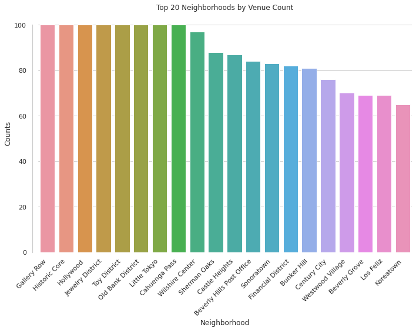

```python
# define the barplot to observe the distribution visually
sns.set(style= 'whitegrid', context = 'notebook', palette='bright')
plt.figure(figsize = (10, 8))

sns.barplot(
    data = lvf3_plot,
    x = lvf3_plot['Neighborhood'],
    y = lvf3_plot['Counts'],
).set_title('Top 20 Neighborhoods by Venue Count')


plt.xticks(rotation = 45, ha ='right')
sns.despine(offset = 10, trim = True, bottom = True)
plt.tight_layout(h_pad = 2)
```

### Hollywood:

Knowing that the Jewelry, Cahuenga Pass, Old Bank, Toy, Gallery Row, Historic Core, Little Tokyo, and Hollywood Districts / Neighborhoods are >= 100 venues, we can investigate their venue distributions to better understand the types of areas they are.

```python
# We're going to create a df that ranks the top 20 venues in the Hollywood District
la_hw = la_venues_final[la_venues_final['Neighborhood'].str.contains('^Hollywood$')].copy()
del la_hw['Counts']
la_hw['Counts'] = la_hw.groupby('Venue Category')['Neighborhood'].transform('count')
la_hw = la_hw.groupby('Venue Category')['Counts'].unique()
la_hwplot = pd.DataFrame({'Venue Category':la_hw.index, 'Counts':la_hw.values})
la_hwplot['Counts'] = la_hwplot['Counts'].astype(str) # convert column to str to remove []
la_hwplot['Counts'] = la_hwplot['Counts'].str.strip('[]') # remove []
la_hwplot['Counts'] = la_hwplot['Counts'].astype(float)
la_hwplot = la_hwplot.sort_values(['Counts'], ascending = False) # sort to find the top districts
la_hwplot = la_hwplot.reset_index(drop=True) # reset index
la_hwplot = la_hwplot.head(20)
```

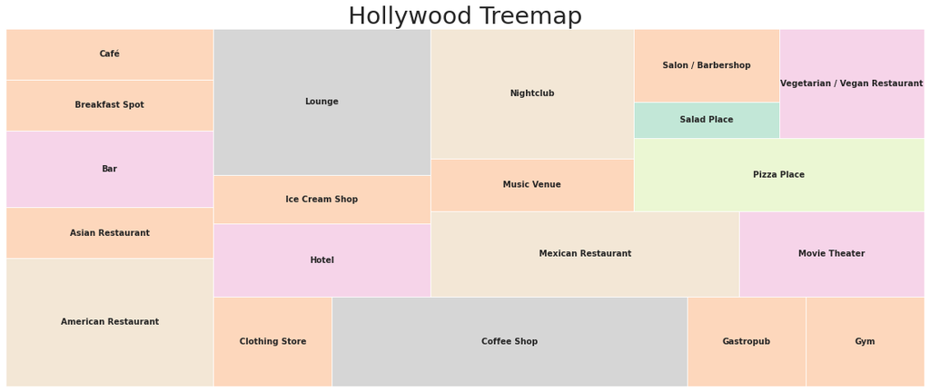

```python
# treemap using squarify to see the distribution of venues in the Jewelry District
plt.figure(figsize = (20, 8))

a = la_hwplot.groupby('Venue Category')[['Counts']].sum().index.get_level_values(0).tolist()
d = la_hwplot.groupby('Venue Category')[['Counts']].sum().reset_index().Counts.values.tolist()

# create a color palette, mapped to these values
cmap = matplotlib.cm.Pastel2

mini = min(d)
maxi = max(d)
norm = matplotlib.colors.Normalize(vmin = mini, vmax = maxi)
colors = [cmap(norm(value)) for value in d]

squarify.plot(sizes = d, label = a, color = colors, alpha = .8,
              text_kwargs={'fontsize':10, 'weight':'bold'})

plt.title('Hollywood Treemap', fontsize = 29)
plt.axis('off')
plt.show()
```

The treemap shows that Coffee Shops are top of the list, while Cafes also feature. This is likely a very popular district for socializing, while a quick investigation of the bottom of the list finds places like libraries, grocery stores and Farmers' markets are less sought-after.

### Beverly Grove:

```python
# the df la_bg will serve to rank the top 20 venues in Beverly Grove
la_bg = la_venues_final[la_venues_final['Neighborhood'].str.contains('Beverly Grove')].copy()
del la_bg['Counts']
la_bg['Counts'] = la_bg.groupby('Venue Category')['Neighborhood'].transform('count')
la_bg = la_bg.groupby('Venue Category')['Counts'].unique()
la_bg = pd.DataFrame({'Venue Category':la_bg.index, 'Counts':la_bg.values})
la_bg['Counts'] = la_bg['Counts'].astype(str) # convert column to str to remove []
la_bg['Counts'] = la_bg['Counts'].str.strip('[]') # remove []
la_bg['Counts'] = la_bg['Counts'].astype(float)
la_bg = la_bg.sort_values(['Counts'], ascending = False) # sort to find the top districts
la_bg = la_bg.reset_index(drop=True) # reset index
la_bg = la_bg.head(20)
```

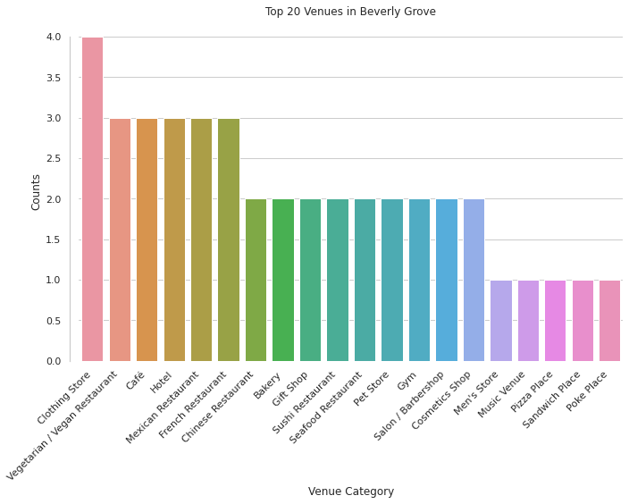

```python
# plot the barplot for Beverly Grove
sns.set(style= 'whitegrid', context = 'notebook', palette='bright')
plt.figure(figsize = (10, 8))

sns.barplot(
    data = la_bg,
    x = la_bg['Venue Category'],
    y = la_bg['Counts'],
).set_title('Top 20 Venues in Beverly Grove')


plt.xticks(rotation = 45, ha ='right')
sns.despine(offset = 10, trim = True, bottom = True)
plt.tight_layout(h_pad = 2)
```

### Koreatown:

Koreatown, the neighborhood with the fewest number of venues in our distribution, should provide some contrast to those venues with >= 100 venues.

```python
# create a dataframe to list the top 20 venues for our barplot
la_kt = la_venues_final[la_venues_final['Neighborhood'].str.contains('Koreatown')].copy()
del la_kt['Counts']
la_kt['Counts'] = la_kt.groupby('Venue Category')['Neighborhood'].transform('count')
la_kt = la_kt.groupby('Venue Category')['Counts'].unique()
la_kt = pd.DataFrame({'Venue Category':la_kt.index, 'Counts':la_kt.values})
la_kt['Counts'] = la_kt['Counts'].astype(str) # convert column to str to remove []
la_kt['Counts'] = la_kt['Counts'].str.strip('[]') # remove []
la_kt['Counts'] = la_kt['Counts'].astype(float)
la_kt = la_kt.sort_values(['Counts'], ascending = False) # sort to find the top districts
la_kt = la_kt.reset_index(drop=True) # reset index
la_kt = la_kt.head(20)
```

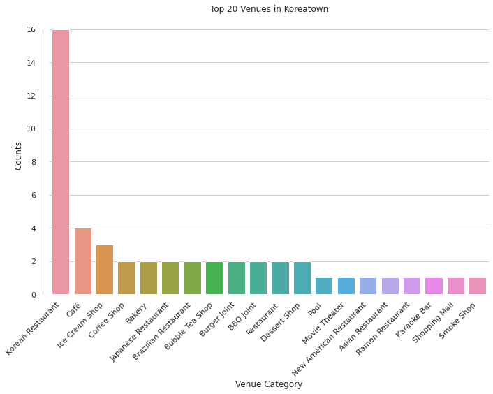

```python
# create a barplot to visualize the distribution of venues in Koreatown
sns.set(style = 'whitegrid', context = 'notebook', palette = 'bright')
plt.figure(figsize = (10, 8))

sns.barplot(
    data = la_kt,
    x = la_kt['Venue Category'],
    y = la_kt['Counts'],
).set_title('Top 20 Venues in Koreatown')


plt.xticks(rotation = 45, ha ='right')
sns.despine(offset = 10, trim = True, bottom = True)
plt.tight_layout(h_pad = 2)
```

While Korean restaurants are enormously popular, both Cafes and Coffee Shops are in the top 4 venues. It is probably reasonable to say Koreatown is a potential hotspot for coffee drinkers to frequent.

### Target: Coffee Shops

The aim of our process is to identify suitable neighorhoods to open an artisanal coffee shop. As such, we will begin by first noting the different types of venues in which coffee is traditionally served. These instances in our dataframe include "Coffee Shop," "Cafe," (along with the alternative convention "Café" placing a diacritic mark over the e). Restaurants are also likely to serve coffee, however due to the wide scope of dishes served, we will not include them in this part of our analysis. We will also remove "Cafeteria" as they are self-serve restaurants, not coffee shops.

```python
# Filter out new df "la_cafe" for the keywords above while removing "Cafeteria"
selected_cols = ['Venue' or 'Venue Category']
la_cafe = la_venues_final.loc[~la_venues_final[selected_cols].apply(lambda x: x.str.contains('Cafeteria')).all(axis=1)]
la_cafe = la_cafe[la_cafe[selected_cols].apply(lambda x: x.str.contains('Café|Cafe|Coffee')).all(axis=1)]
la_cafe.reset_index(inplace = True, drop = True)
len(la_cafe) # Check the total number of listings that fit our criteria
```

```
262
```

### Visualization: Coffee Shops by Neighborhood

Now we're going to build a df to plot a barchart of the top 20 neighborhoods with coffee shops.

```python
la_cafe['Counts'] = la_cafe.groupby('Neighborhood')['Neighborhood'].transform('count') # mutate column "Counts"
la_cafe2 = la_cafe.groupby('Neighborhood')['Counts'].unique() # groupby the newly created column
la_counts = pd.DataFrame({'Neighborhood':la_cafe2.index, 'Counts':la_cafe2.values}) # convert the series to df
la_counts['Counts'] = la_counts['Counts'].astype(str) # convert column to str to remove []
la_counts['Counts'] = la_counts['Counts'].str.strip('[]') # remove []
la_counts['Counts'] = la_counts['Counts'].astype(float) # convert to float
la_counts = la_counts.sort_values(['Counts'], ascending = False) # sort to find the top districts
la_counts = la_counts.reset_index(drop=True) # reset index
la_counts_plot = la_counts.head(20)
```

Let's visualize this with a barplot

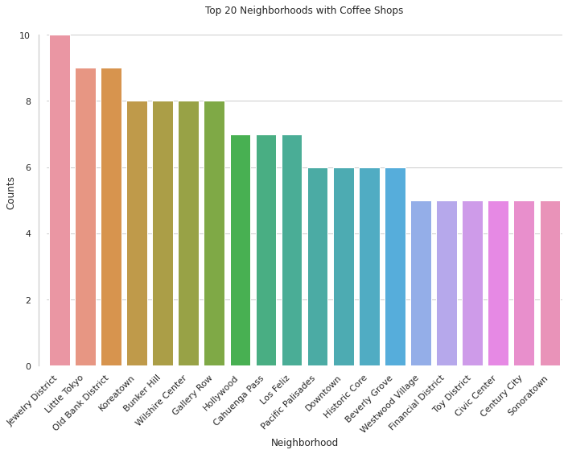

```python
sns.set(style= "whitegrid", context = "notebook", palette="bright")
plt.figure(figsize = (10, 8))

sns.barplot(
    data = la_counts_plot,
    x = la_counts_plot["Neighborhood"],
    y = la_counts_plot["Counts"],
).set_title('Top 20 Neighborhoods with Coffee Shops')


plt.xticks(rotation = 45, ha ='right')
sns.despine(offset = 10, trim = True, bottom = True)
plt.tight_layout(h_pad = 2)
```

### Visualization: Cafe Location Distribution

Let's explore a visual distribution of coffee shops in LA to confirm the data presented in the barplot.

```python
# title the cafe_heatmap
cafe_heatmap = folium.Map(location = [latitude, longitude], zoom_start = 10)
```

```python
# create the heatmap to be added to the original la_map
heat_data = [[ row['Neighborhood Latitude'], row['Neighborhood Longitude']] for index, row in la_cafe.iterrows()]
HeatMap(heat_data).add_to(cafe_heatmap)
```

```
<folium.plugins.heat_map.HeatMap at 0x7f4a0eebe048>
```

The labels will reflect different coffee shops and cafes found in our df "la_cafe" while the density in the heatmap reflects the number of occurrences of neighborhoods with coffee shops or cafes in them.

```python
# plot an interactive folium heatmap with venue labels to visualize where cafes are located in LA
for lat, lng, venue in zip(
        la_cafe['Venue Latitude'],
        la_cafe['Venue Longitude'],
        la_cafe['Venue']):
    label = '{}'.format(venue)
    label = folium.Popup(label, parse_html = True)
    folium.CircleMarker(
        [lat, lng],
        radius = 5,
        popup = label,
        color = 'blue',
        fill = True,
        fill_color = '#3186cc',
        fill_opacity = 0.7,
        parse_html = False).add_to(cafe_heatmap)

cafe_heatmap
```

Make this Notebook Trusted to load map: File -> Trust Notebook

[interactive chart not shown]

A cursory review of the map indicates the most dense clusters are unsurprisingly located around Downtown LA, the Jewelry District, Chinatown, the Little Tokyo Historic District, Beverly Hills, and Westwood with some outliers surrounding Long Beach and the San Fernando Valley.

## Rental Data:

Our LA average monthly rental data will be scraped from RENTCafe as it has a very extensive and well-maintained list of average monthly rents by neighborhood (All values are in US Dollars).

```python
# Scrape and parse data from Wikipedia with requests and BeautifulSoup
url2 = 'https://www.rentcafe.com/average-rent-market-trends/us/ca/los-angeles/'
```

```python
# After inspecting the html on RENTCafe, it's apparent we can simply scrape the second table on the page
r = requests.get(url2)
rent_list = pd.read_html(r.text) # this parses all the tables in webpages to a list
la_rent = rent_list[2] # create the new df "la_rent"
la_rent['Average Rent'] = la_rent['Average Rent'].str.strip('$') # remove the $
la_rent['Average Rent'] = la_rent['Average Rent'].str.replace(',', '') # remove the comma
la_rent['Average Rent'] = la_rent['Average Rent'].astype(float) # convert to float for plotting
la_rent_vis = la_rent.head(10) # sort the top 10
la_rent.shape # let's check the shape
```

```
(121, 2)
```

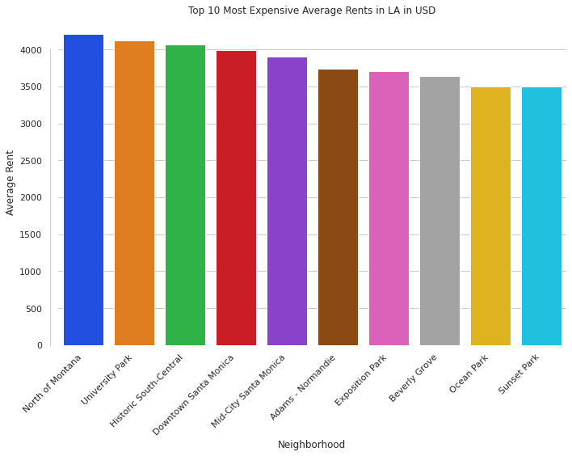

```python
# create the barplot using the la_rent_vis df created above
sns.set(style= 'whitegrid', context = 'notebook', palette = 'bright')
plt.figure(figsize = (10, 8))

sns.barplot(
    data = la_rent_vis,
    x = la_rent_vis['Neighborhood'],
    y = la_rent_vis['Average Rent'],
).set_title('Top 10 Most Expensive Average Rents in LA in USD')


plt.xticks(rotation = 45, ha ='right')
sns.despine(offset = 10, trim = True, bottom = True)
plt.tight_layout(h_pad = 2)
```

After loading the new dataframe, we notice there are two columns: "Neighborhood", and "Average Rent" and that there are 121 neighborhoods listed.

### Average & Median Rent in LA:

Using our dataset, let's calculate the average and median cost of rent in LA:

```python
print('The average rent in LA is {}.'.format(la_rent['Average Rent'].mean()))
print('The median rent in LA is {}.'.format(la_rent['Average Rent'].median()))
```

```
The average rent in LA is 2365.9173553719006.
The median rent in LA is 2234.0.
```

The mean and median rents in LA are relatively close in value, though they are signficantly more expensive than the average cost of rent in the US (USD 1124) as defined by [Statista](https://www.statista.com/statistics/1063502/average-monthly-apartment-rent-usa/) in 2021. This speaks to LA's high cost of living and the purchasing power tenants in the city require in order to afford rent.

### Now let's join the "neighborhoods" and "la_rent" dataframes

```python
la_nh = pd.merge(neighborhoods, la_rent, on = 'Neighborhood')
print(la_nh.shape)
la_nh.head()
```

```
(91, 4)
```

|  | Neighborhood | Latitude | Longitude | Average Rent |
| --- | --- | --- | --- | --- |
| 0 | Arleta | 34.241327 | -118.432205 | 1708.0 |
| 1 | Arlington Heights | 34.043494 | -118.321374 | 1487.0 |
| 2 | Atwater Village | 34.116398 | -118.256464 | 2070.0 |
| 3 | Bel Air | 34.082728 | -118.447980 | 2850.0 |
| 4 | Beverly Grove | 34.076034 | -118.369972 | 3642.0 |

Of the differences in the two tables, there are 91 total neighborhood matches and our final dataframe consists of four columns "Neighborhood," "Latitude," "Longitude," and "Average Rent" with which to begin our analysis.

### Rent vs Coffee Shop Frequency Correlation

Let's merge our la_nh & la_counts dataframes to determine whether there is any correlation between the average cost of rent in a neighborhood and the incidence of coffee shops.

```python
la_cor = pd.merge(la_nh, la_counts, on = 'Neighborhood')
```

```python
la_cor.head()
```

|  | Neighborhood | Latitude | Longitude | Average Rent | Counts |
| --- | --- | --- | --- | --- | --- |
| 0 | Arlington Heights | 34.043494 | -118.321374 | 1487.0 | 1.0 |
| 1 | Atwater Village | 34.116398 | -118.256464 | 2070.0 | 2.0 |
| 2 | Bel Air | 34.082728 | -118.447980 | 2850.0 | 1.0 |
| 3 | Beverly Grove | 34.076034 | -118.369972 | 3642.0 | 6.0 |
| 4 | Boyle Heights | 34.043689 | -118.209768 | 1991.0 | 1.0 |

Just by examining the first few rows, we can already see Beverly Grove, with a very expensive average rent at $3642 also has the highest number of coffee venues. Let's explore this further with a correlogram.

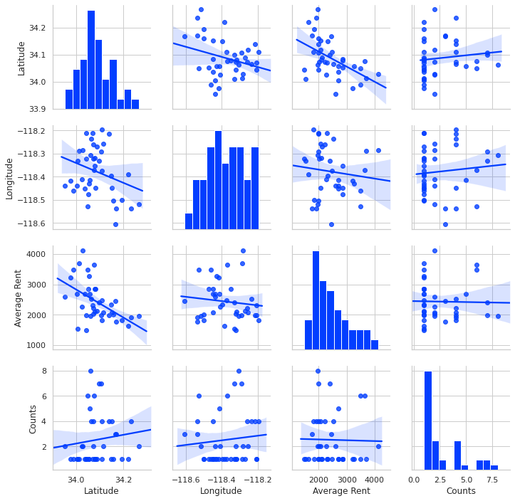

```python
cor_plot = sns.pairplot(la_cor, kind="reg", palette="Set2")
cor_plot
```

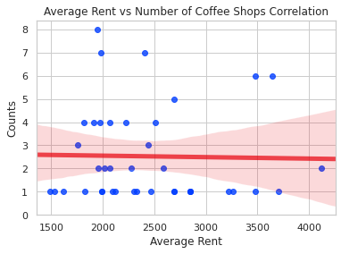

```python
# let's take a closer look at the scatterplot with a regression line
sns.regplot(x = la_cor["Average Rent"], y = la_cor["Counts"], line_kws = {"color":"r","alpha":0.7,"lw":5})
plt.title('Average Rent vs Number of Coffee Shops Correlation')
plt.show()
```

It appears most neighborhoods have fewer than 4 venues and that the average rent is generally below $2800. Let's perform clustering on our data to determine further potential insights.

## Clustering Preparation:

```python
# drop the "Counts" column as it references the instances of coffee shops per neighborhood
la_venues_final = la_venues_final.drop(columns = ['Counts'])
la_venues_final.head()
```

|  | Neighborhood | Neighborhood Latitude | Neighborhood Longitude | Venue | Venue Latitude | Venue Longitude | Venue Category | Overall Category |
| --- | --- | --- | --- | --- | --- | --- | --- | --- |
| 0 | Angelino Heights | 34.070289 | -118.254796 | Halliwell Manor | 34.069329 | -118.254165 | Performing Arts Venue | Arts & Entertainment |
| 1 | Arts District | 34.041239 | -118.234450 | 6th Street Warehouse | 34.038450 | -118.236745 | Performing Arts Venue | Arts & Entertainment |
| 2 | Atwater Village | 34.116398 | -118.256464 | Atwater Village Theatre | 34.116282 | -118.252010 | Performing Arts Venue | Arts & Entertainment |
| 3 | Beverly Hills Post Office | 34.072480 | -118.401707 | Wallis Annenberg Center for Performing Arts | 34.072437 | -118.401879 | Performing Arts Venue | Arts & Entertainment |
| 4 | Bunker Hill | 34.055066 | -118.251223 | Dorothy Chandler Pavilion | 34.056625 | -118.248886 | Performing Arts Venue | Arts & Entertainment |

Neighborhood Analysis with one hot encoding:

Let's use pd.get_dummies to convert our categorial categories into numerical data for further analysis.

```python
# one hot encoding
la_onehot = pd.get_dummies(la_venues_final[['Venue Category']], prefix="", prefix_sep="")

# add neighborhood column back to dataframe
la_onehot['Neighborhood'] = la_venues_final['Neighborhood']

del list # remove previous html list
# move neighborhood column to the first column
ohcols = list(la_onehot) # get a list of columns

# move the column to head of list using index
ohcols.insert(0, ohcols.pop(ohcols.index('Neighborhood')))

la_onehot = la_onehot[ohcols]
print(la_onehot.shape)
la_onehot.head()
```

```
(4660, 342)
```

|  | Neighborhood | ATM | Accessories Store | Adult Boutique | Airport Lounge | Airport Terminal | American Restaurant | Amphitheater | Andhra Restaurant | Aquarium | ... | Vietnamese Restaurant | Volleyball Court | Watch Shop | Whisky Bar | Wine Bar | Wine Shop | Wings Joint | Women's Store | Yoga Studio | Yoshoku Restaurant |
| --- | --- | --- | --- | --- | --- | --- | --- | --- | --- | --- | --- | --- | --- | --- | --- | --- | --- | --- | --- | --- | --- |
| 0 | Angelino Heights | 0 | 0 | 0 | 0 | 0 | 0 | 0 | 0 | 0 | ... | 0 | 0 | 0 | 0 | 0 | 0 | 0 | 0 | 0 | 0 |
| 1 | Arts District | 0 | 0 | 0 | 0 | 0 | 0 | 0 | 0 | 0 | ... | 0 | 0 | 0 | 0 | 0 | 0 | 0 | 0 | 0 | 0 |
| 2 | Atwater Village | 0 | 0 | 0 | 0 | 0 | 0 | 0 | 0 | 0 | ... | 0 | 0 | 0 | 0 | 0 | 0 | 0 | 0 | 0 | 0 |
| 3 | Beverly Hills Post Office | 0 | 0 | 0 | 0 | 0 | 0 | 0 | 0 | 0 | ... | 0 | 0 | 0 | 0 | 0 | 0 | 0 | 0 | 0 | 0 |
| 4 | Bunker Hill | 0 | 0 | 0 | 0 | 0 | 0 | 0 | 0 | 0 | ... | 0 | 0 | 0 | 0 | 0 | 0 | 0 | 0 | 0 | 0 |

5 rows × 342 columns

Group rows by neighborhood and by taking the sum instead of the mean of each occurrence per category for a cleaner table.

```python
# use groupby to sort the table
la_grouped = la_onehot.groupby('Neighborhood').sum().reset_index()
la_grouped.head()
```

|  | Neighborhood | ATM | Accessories Store | Adult Boutique | Airport Lounge | Airport Terminal | American Restaurant | Amphitheater | Andhra Restaurant | Aquarium | ... | Vietnamese Restaurant | Volleyball Court | Watch Shop | Whisky Bar | Wine Bar | Wine Shop | Wings Joint | Women's Store | Yoga Studio | Yoshoku Restaurant |
| --- | --- | --- | --- | --- | --- | --- | --- | --- | --- | --- | --- | --- | --- | --- | --- | --- | --- | --- | --- | --- | --- |
| 0 | Angeles Mesa | 0 | 0 | 0 | 0 | 0 | 0 | 0 | 0 | 0 | ... | 0 | 0 | 0 | 0 | 1 | 0 | 0 | 0 | 0 | 0 |
| 1 | Angelino Heights | 0 | 0 | 0 | 0 | 0 | 0 | 0 | 0 | 0 | ... | 0 | 0 | 0 | 0 | 0 | 0 | 0 | 0 | 0 | 0 |
| 2 | Arleta | 0 | 0 | 0 | 0 | 0 | 0 | 0 | 0 | 0 | ... | 0 | 0 | 0 | 0 | 0 | 0 | 0 | 0 | 0 | 0 |
| 3 | Arlington Heights | 0 | 0 | 0 | 0 | 0 | 0 | 0 | 0 | 0 | ... | 0 | 0 | 0 | 0 | 0 | 0 | 0 | 0 | 0 | 0 |
| 4 | Arts District | 0 | 0 | 0 | 0 | 0 | 0 | 0 | 0 | 0 | ... | 0 | 0 | 0 | 0 | 1 | 0 | 0 | 0 | 0 | 0 |

5 rows × 342 columns

```python
# groupby Neighborhood values by their mean venue occurrences for later k-means analysis
la_grouped_mean = la_onehot.groupby('Neighborhood').mean().reset_index()
la_grouped_mean.head()
```

|  | Neighborhood | ATM | Accessories Store | Adult Boutique | Airport Lounge | Airport Terminal | American Restaurant | Amphitheater | Andhra Restaurant | Aquarium | ... | Vietnamese Restaurant | Volleyball Court | Watch Shop | Whisky Bar | Wine Bar | Wine Shop | Wings Joint | Women's Store | Yoga Studio | Yoshoku Restaurant |
| --- | --- | --- | --- | --- | --- | --- | --- | --- | --- | --- | --- | --- | --- | --- | --- | --- | --- | --- | --- | --- | --- |
| 0 | Angeles Mesa | 0.0 | 0.0 | 0.0 | 0.0 | 0.0 | 0.0 | 0.0 | 0.0 | 0.0 | ... | 0.0 | 0.0 | 0.0 | 0.0 | 0.125000 | 0.0 | 0.0 | 0.0 | 0.0 | 0.0 |
| 1 | Angelino Heights | 0.0 | 0.0 | 0.0 | 0.0 | 0.0 | 0.0 | 0.0 | 0.0 | 0.0 | ... | 0.0 | 0.0 | 0.0 | 0.0 | 0.000000 | 0.0 | 0.0 | 0.0 | 0.0 | 0.0 |
| 2 | Arleta | 0.0 | 0.0 | 0.0 | 0.0 | 0.0 | 0.0 | 0.0 | 0.0 | 0.0 | ... | 0.0 | 0.0 | 0.0 | 0.0 | 0.000000 | 0.0 | 0.0 | 0.0 | 0.0 | 0.0 |
| 3 | Arlington Heights | 0.0 | 0.0 | 0.0 | 0.0 | 0.0 | 0.0 | 0.0 | 0.0 | 0.0 | ... | 0.0 | 0.0 | 0.0 | 0.0 | 0.000000 | 0.0 | 0.0 | 0.0 | 0.0 | 0.0 |
| 4 | Arts District | 0.0 | 0.0 | 0.0 | 0.0 | 0.0 | 0.0 | 0.0 | 0.0 | 0.0 | ... | 0.0 | 0.0 | 0.0 | 0.0 | 0.028571 | 0.0 | 0.0 | 0.0 | 0.0 | 0.0 |

5 rows × 342 columns

```python
# join the grouped means with la_rent for k-means
la_grouped_mean_rent = pd.merge(la_rent, la_grouped_mean, on = 'Neighborhood')
la_grouped_mean_rent.head()
```

|  | Neighborhood | Average Rent | ATM | Accessories Store | Adult Boutique | Airport Lounge | Airport Terminal | American Restaurant | Amphitheater | Andhra Restaurant | ... | Vietnamese Restaurant | Volleyball Court | Watch Shop | Whisky Bar | Wine Bar | Wine Shop | Wings Joint | Women's Store | Yoga Studio | Yoshoku Restaurant |
| --- | --- | --- | --- | --- | --- | --- | --- | --- | --- | --- | --- | --- | --- | --- | --- | --- | --- | --- | --- | --- | --- |
| 0 | University Park | 4123.0 | 0.000000 | 0.0 | 0.0 | 0.0 | 0.0 | 0.000000 | 0.000000 | 0.0 | ... | 0.0 | 0.0 | 0.000 | 0.0 | 0.0 | 0.0 | 0.0 | 0.0 | 0.0 | 0.0 |
| 1 | Exposition Park | 3703.0 | 0.000000 | 0.0 | 0.0 | 0.0 | 0.0 | 0.000000 | 0.022727 | 0.0 | ... | 0.0 | 0.0 | 0.000 | 0.0 | 0.0 | 0.0 | 0.0 | 0.0 | 0.0 | 0.0 |
| 2 | Beverly Grove | 3642.0 | 0.000000 | 0.0 | 0.0 | 0.0 | 0.0 | 0.000000 | 0.000000 | 0.0 | ... | 0.0 | 0.0 | 0.000 | 0.0 | 0.0 | 0.0 | 0.0 | 0.0 | 0.0 | 0.0 |
| 3 | Pacific Palisades | 3481.0 | 0.037736 | 0.0 | 0.0 | 0.0 | 0.0 | 0.037736 | 0.000000 | 0.0 | ... | 0.0 | 0.0 | 0.000 | 0.0 | 0.0 | 0.0 | 0.0 | 0.0 | 0.0 | 0.0 |
| 4 | Venice | 3480.0 | 0.000000 | 0.0 | 0.0 | 0.0 | 0.0 | 0.000000 | 0.000000 | 0.0 | ... | 0.0 | 0.0 | 0.025 | 0.0 | 0.0 | 0.0 | 0.0 | 0.0 | 0.0 | 0.0 |

5 rows × 343 columns

Let's rearrange the table and include the top 5 venues for each neighborhood.

```python
# define a function to sort values by descending order
def return_most_common_venues(row, num_top_venues):
    row_categories = row.iloc[1:]
    row_categories_sorted = row_categories.sort_values(ascending=False)

    return row_categories_sorted.index.values[0:num_top_venues]
```

```python
# assign a vector for the top 5 venues
num_top_venues = 5

indicators = ['st', 'nd', 'rd']

# create columns according to number of top venues
columns = ['Neighborhood']
for ind in np.arange(num_top_venues):
    try:
        columns.append('{}{} Most Common Venue'.format(ind+1, indicators[ind]))
    except:
        columns.append('{}th Most Common Venue'.format(ind+1))

# create a new dataframe
la_ven_sorted = pd.DataFrame(columns=columns)
la_ven_sorted['Neighborhood'] = la_grouped_mean['Neighborhood']

for ind in np.arange(la_grouped_mean.shape[0]):
    la_ven_sorted.iloc[ind, 1:] = return_most_common_venues(la_grouped_mean.iloc[ind, :], num_top_venues)

print(la_ven_sorted.shape)
la_ven_sorted.head()
```

```
(176, 6)
```

|  | Neighborhood | 1st Most Common Venue | 2nd Most Common Venue | 3rd Most Common Venue | 4th Most Common Venue | 5th Most Common Venue |
| --- | --- | --- | --- | --- | --- | --- |
| 0 | Angeles Mesa | Deli / Bodega | Pet Store | Burger Joint | Wine Bar | Restaurant |
| 1 | Angelino Heights | Japanese Restaurant | Coffee Shop | BBQ Joint | Trail | Bakery |
| 2 | Arleta | Movie Theater | Historic Site | Beach Bar | Yoshoku Restaurant | Financial or Legal Service |
| 3 | Arlington Heights | Rental Car Location | Café | Grocery Store | Latin American Restaurant | Convenience Store |
| 4 | Arts District | Coffee Shop | Italian Restaurant | Art Gallery | Cocktail Bar | Food Truck |

```python
# add la_rent to the table
la_grouped_rent = pd.merge(la_rent, la_ven_sorted, on = 'Neighborhood')
la_grouped_rent.head()
```

|  | Neighborhood | Average Rent | 1st Most Common Venue | 2nd Most Common Venue | 3rd Most Common Venue | 4th Most Common Venue | 5th Most Common Venue |
| --- | --- | --- | --- | --- | --- | --- | --- |
| 0 | University Park | 4123.0 | Coffee Shop | Shipping Store | Paper / Office Supplies Store | Food Truck | Italian Restaurant |
| 1 | Exposition Park | 3703.0 | Science Museum | History Museum | Food Court | Museum | Sandwich Place |
| 2 | Beverly Grove | 3642.0 | Clothing Store | Hotel | Café | French Restaurant | Mexican Restaurant |
| 3 | Pacific Palisades | 3481.0 | Ice Cream Shop | Coffee Shop | ATM | Italian Restaurant | Gym |
| 4 | Venice | 3480.0 | Boutique | Clothing Store | Café | New American Restaurant | Men's Store |

```python
# add the Latitude and Longitude Columns back into the table
la_grouped = pd.merge(neighborhoods, la_grouped_rent, on = 'Neighborhood')
la_grouped.head()
```

|  | Neighborhood | Latitude | Longitude | Average Rent | 1st Most Common Venue | 2nd Most Common Venue | 3rd Most Common Venue | 4th Most Common Venue | 5th Most Common Venue |
| --- | --- | --- | --- | --- | --- | --- | --- | --- | --- |
| 0 | Arleta | 34.241327 | -118.432205 | 1708.0 | Movie Theater | Historic Site | Beach Bar | Yoshoku Restaurant | Financial or Legal Service |
| 1 | Arlington Heights | 34.043494 | -118.321374 | 1487.0 | Rental Car Location | Café | Grocery Store | Latin American Restaurant | Convenience Store |
| 2 | Atwater Village | 34.116398 | -118.256464 | 2070.0 | Pet Store | Gym | Sporting Goods Shop | Restaurant | Pizza Place |
| 3 | Bel Air | 34.082728 | -118.447980 | 2850.0 | Hotel Bar | Restaurant | Hotel Pool | Golf Course | Spa |
| 4 | Beverly Grove | 34.076034 | -118.369972 | 3642.0 | Clothing Store | Hotel | Café | French Restaurant | Mexican Restaurant |

### Modeling: K-Means Clustering

This unsupervised and iterative machine-learning algorithm is often applied to messy real-world data such as consumer data for market segmentation and geospatial data for location-based analysis. It parses datasets with numerous observations into k clusters based on a centroid or simply a cluster with the nearest mean.

The algorithm attempts to create homogeneous subcategories by minimizing the sum of the squared Euclidean distance between data points in a specific cluster. As such, an interesting feature of k-means clustering is that the distance between individual clusters is as geometrically distant as possible in order to reinforce potential distinctions between the cluster's observations.

Additionally, the K-means algorithm's is particularly effective when clusters are spherical which is often the case with geospatial datasets. Its numerous applications in gleaning insights on location-based data as well as its demonstrated industry track record are the reasons why it has been selected to further illuminate our dataset.

```python
# finding the best k
from sklearn import metrics
from sklearn.preprocessing import StandardScaler
from scipy.spatial.distance import cdist

la_kmeans = la_grouped_mean_rent.drop(columns = ['Neighborhood']) # drop categorical column
X = la_kmeans.values[:,1:] # define individual arrays
X = np.nan_to_num(X)
la_elbow = StandardScaler().fit_transform(X) # use StandardScaler to reshape and normalize
```

```python
distortions = [] # create list "distortions"
mapping1 = {} # define mapping

K = range(1, 10) # establish k range

for k in K:
    # build and fit the model
    kmeanModel = KMeans(n_clusters=k).fit(la_elbow)
    kmeanModel.fit(la_elbow)

    distortions.append(sum(np.min(cdist(la_elbow, kmeanModel.cluster_centers_,
                                        'euclidean'), axis=1)) / la_elbow.shape[0])

    mapping1[k] = sum(np.min(cdist(la_elbow, kmeanModel.cluster_centers_,
                                   'euclidean'), axis=1)) / la_elbow.shape[0]
```

### Visualize Optimal Value K

With the k-means algorithm, the k value is sometimes arbitrarily assigned to a certain value (usually 5 similar to our previous labs). It is, however, better to use the "Elbow Method" to determine the optimal k value in a certain range, which we will do below.

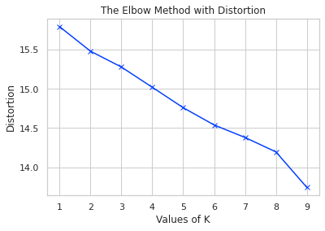

```python
# plot the optimal k using the Elbow Method
plt.plot(K, distortions, 'bx-')
plt.xlabel('Values of K')
plt.ylabel('Distortion')
plt.title('The Elbow Method with Distortion')
plt.show()
```

The optimal value using distortion occurs when the "elbow" stops decreasing at a linear rate and takes place in our range between 5 and 6 therefore we will assign a kcluster value of 5.

```python
# set number of clusters
kclusters = 5

# run k-means clustering
kmeans = KMeans(n_clusters = kclusters, random_state = 0).fit(la_elbow)

# check cluster labels generated for each row in the dataframe
kmeans.labels_[0:10]
```

```
array([1, 0, 2, 0, 2, 2, 2, 0, 0, 2], dtype=int32)
```

```python
# add clustering labels
la_grouped.insert(4, 'Cluster Labels', kmeans.labels_)
```

```python
# change the table name to "la_merged"
la_merged = la_grouped
la_merged.head()
```

|  | Neighborhood | Latitude | Longitude | Average Rent | Cluster Labels | 1st Most Common Venue | 2nd Most Common Venue | 3rd Most Common Venue | 4th Most Common Venue | 5th Most Common Venue |
| --- | --- | --- | --- | --- | --- | --- | --- | --- | --- | --- |
| 0 | Arleta | 34.241327 | -118.432205 | 1708.0 | 1 | Movie Theater | Historic Site | Beach Bar | Yoshoku Restaurant | Financial or Legal Service |
| 1 | Arlington Heights | 34.043494 | -118.321374 | 1487.0 | 0 | Rental Car Location | Café | Grocery Store | Latin American Restaurant | Convenience Store |
| 2 | Atwater Village | 34.116398 | -118.256464 | 2070.0 | 2 | Pet Store | Gym | Sporting Goods Shop | Restaurant | Pizza Place |
| 3 | Bel Air | 34.082728 | -118.447980 | 2850.0 | 0 | Hotel Bar | Restaurant | Hotel Pool | Golf Course | Spa |
| 4 | Beverly Grove | 34.076034 | -118.369972 | 3642.0 | 2 | Clothing Store | Hotel | Café | French Restaurant | Mexican Restaurant |

### Visualize Clusters:

```python
#visualize the resulting clusters

# create map
map_clusters = folium.Map(location=[latitude, longitude], zoom_start = 10)

# set color scheme for the clusters
x = np.arange(kclusters)
ys = [i + x + (i*x)**2 for i in range(kclusters)]
colors_array = cm.rainbow(np.linspace(0, 1, len(ys)))
rainbow = [colors.rgb2hex(i) for i in colors_array]

# add markers to the map
markers_colors = []
for lat, lon, poi, cluster in zip(la_merged['Latitude'], la_merged['Longitude'], la_merged['Neighborhood'], la_merged['Cluster Labels']):
    label = folium.Popup(str(poi) + ' Cluster ' + str(cluster), parse_html = True)
    folium.CircleMarker(
        [lat, lon],
        radius = 5,
        popup = label,
        color = rainbow[cluster-1],
        fill = True,
        fill_color = rainbow[cluster-1],
        fill_opacity = 0.7).add_to(map_clusters)

map_clusters
```

Make this Notebook Trusted to load map: File -> Trust Notebook

[interactive chart not shown]

**Our clusters will be labeled from 1-5 (even though the index starts at 0) for the purpose of clarity.**

### Cluster 1 (Red)

```python
la_merged.loc[la_merged['Cluster Labels'] == 0, la_merged.columns[[0]+[1]+[2] + list(range(3, la_merged.shape[1]))]]
```

|  | Neighborhood | Latitude | Longitude | Average Rent | Cluster Labels | 1st Most Common Venue | 2nd Most Common Venue | 3rd Most Common Venue | 4th Most Common Venue | 5th Most Common Venue |
| --- | --- | --- | --- | --- | --- | --- | --- | --- | --- | --- |
| 1 | Arlington Heights | 34.043494 | -118.321374 | 1487.0 | 0 | Rental Car Location | Café | Grocery Store | Latin American Restaurant | Convenience Store |
| 3 | Bel Air | 34.082728 | -118.447980 | 2850.0 | 0 | Hotel Bar | Restaurant | Hotel Pool | Golf Course | Spa |
| 7 | Brentwood | 34.052140 | -118.474070 | 2850.0 | 0 | Spa | Italian Restaurant | Salon / Barbershop | Gym / Fitness Center | Coffee Shop |
| 8 | Canoga Park | 34.201108 | -118.597809 | 2041.0 | 0 | Rental Car Location | Asian Restaurant | Thrift / Vintage Store | Convenience Store | Theater |
| 11 | Chatsworth | 34.259571 | -118.602325 | 2049.0 | 0 | Mexican Restaurant | Vietnamese Restaurant | Convenience Store | Fast Food Restaurant | Spa |
| ... | ... | ... | ... | ... | ... | ... | ... | ... | ... | ... |
| 85 | West Los Angeles | 34.046399 | -118.448135 | 2694.0 | 0 | Japanese Restaurant | Middle Eastern Restaurant | Gym | Mexican Restaurant | Indie Movie Theater |
| 86 | Westwood | 34.056121 | -118.430635 | 3266.0 | 0 | Italian Restaurant | Coffee Shop | Fast Food Restaurant | Hookah Bar | Entertainment Service |
| 87 | Windsor Square | 34.072593 | -118.320810 | 2016.0 | 0 | Coffee Shop | Italian Restaurant | Juice Bar | Bakery | Bank |
| 88 | Winnetka | 34.201321 | -118.571104 | 1524.0 | 0 | Shopping Mall | Convenience Store | Gym / Fitness Center | Coffee Shop | Pizza Place |
| 89 | Woodland Hills | 34.168436 | -118.605838 | 2438.0 | 0 | Sushi Restaurant | Ice Cream Shop | Mediterranean Restaurant | Bagel Shop | Indian Restaurant |

62 rows × 10 columns

### Cluster 2 (Purple)

```python
la_merged.loc[la_merged['Cluster Labels'] == 1, la_merged.columns[[0]+[1]+[2] + list(range(3, la_merged.shape[1]))]]
```

|  | Neighborhood | Latitude | Longitude | Average Rent | Cluster Labels | 1st Most Common Venue | 2nd Most Common Venue | 3rd Most Common Venue | 4th Most Common Venue | 5th Most Common Venue |
| --- | --- | --- | --- | --- | --- | --- | --- | --- | --- | --- |
| 0 | Arleta | 34.241327 | -118.432205 | 1708.0 | 1 | Movie Theater | Historic Site | Beach Bar | Yoshoku Restaurant | Financial or Legal Service |

### Cluster 3 (Blue)

```python
la_merged.loc[la_merged['Cluster Labels'] == 2, la_merged.columns[[0]+[1]+[2] + list(range(3, la_merged.shape[1]))]]
```

|  | Neighborhood | Latitude | Longitude | Average Rent | Cluster Labels | 1st Most Common Venue | 2nd Most Common Venue | 3rd Most Common Venue | 4th Most Common Venue | 5th Most Common Venue |
| --- | --- | --- | --- | --- | --- | --- | --- | --- | --- | --- |
| 2 | Atwater Village | 34.116398 | -118.256464 | 2070.0 | 2 | Pet Store | Gym | Sporting Goods Shop | Restaurant | Pizza Place |
| 4 | Beverly Grove | 34.076034 | -118.369972 | 3642.0 | 2 | Clothing Store | Hotel | Café | French Restaurant | Mexican Restaurant |
| 5 | Beverlywood | 34.045933 | -118.394920 | 2266.0 | 2 | Burrito Place | Park | Yoshoku Restaurant | Flea Market | Fabric Shop |
| 6 | Boyle Heights | 34.043689 | -118.209768 | 1991.0 | 2 | Fast Food Restaurant | Bakery | Mexican Restaurant | Pharmacy | Grocery Store |
| 9 | Carthay | 34.061121 | -118.367300 | 3442.0 | 2 | Italian Restaurant | Bank | Fast Food Restaurant | Hotel | Sushi Restaurant |
| 10 | Century City | 34.057359 | -118.414608 | 2694.0 | 2 | Coffee Shop | Mexican Restaurant | Department Store | Salad Place | Lounge |
| 17 | Eagle Rock | 34.139032 | -118.214096 | 1975.0 | 2 | Mexican Restaurant | Fast Food Restaurant | Chinese Restaurant | Dessert Shop | Coffee Shop |
| 24 | Exposition Park | 34.013654 | -118.287211 | 3703.0 | 2 | Science Museum | History Museum | Food Court | Museum | Sandwich Place |
| 41 | Lake View Terrace | 34.276391 | -118.361191 | 1844.0 | 2 | Trail | Garden | Financial or Legal Service | Ethiopian Restaurant | Event Space |
| 42 | Larchmont | 34.079837 | -118.317870 | 2097.0 | 2 | Intersection | Park | American Restaurant | Gym | Movie Theater |
| 46 | Manchester Square | 33.966374 | -118.313378 | 1809.0 | 2 | Music Venue | Yoga Studio | Burger Joint | Wine Bar | BBQ Joint |
| 48 | Mid-City | 34.041527 | -118.360370 | 2234.0 | 2 | Gym / Fitness Center | Indie Theater | Food Truck | Taco Place | Liquor Store |
| 53 | North Hollywood | 34.172904 | -118.374037 | 2019.0 | 2 | Mexican Restaurant | Rental Car Location | Convenience Store | Burger Joint | North Indian Restaurant |
| 55 | Pacific Palisades | 34.048064 | -118.526471 | 3481.0 | 2 | Ice Cream Shop | Coffee Shop | ATM | Italian Restaurant | Gym |
| 62 | Rancho Park | 34.034173 | -118.426206 | 2388.0 | 2 | Nightclub | Lounge | Burrito Place | Light Rail Station | Yoshoku Restaurant |
| 63 | Reseda | 34.200078 | -118.536988 | 1699.0 | 2 | Vietnamese Restaurant | Chinese Restaurant | Bank | Arts & Crafts Store | Fried Chicken Joint |
| 70 | Sun Valley | 34.220423 | -118.387895 | 1621.0 | 2 | Convenience Store | Grocery Store | Furniture / Home Store | Coffee Shop | Stadium |
| 80 | Vermont Vista | 33.941947 | -118.285814 | 1423.0 | 2 | Burger Joint | Yoshoku Restaurant | Flea Market | Event Space | Fabric Shop |

```python
la_merged.loc[la_merged['Cluster Labels'] == 3, la_merged.columns[[0]+[1]+[2] + list(range(3, la_merged.shape[1]))]]
```

|  | Neighborhood | Latitude | Longitude | Average Rent | Cluster Labels | 1st Most Common Venue | 2nd Most Common Venue | 3rd Most Common Venue | 4th Most Common Venue | 5th Most Common Venue |
| --- | --- | --- | --- | --- | --- | --- | --- | --- | --- | --- |
| 22 | Elysian Valley | 34.095913 | -118.242033 | 2023.0 | 3 | Trail | Rental Car Location | Intersection | Gym / Fitness Center | Burrito Place |
| 34 | Hollywood | 34.098003 | -118.329523 | 2402.0 | 3 | Lounge | Coffee Shop | Mexican Restaurant | Nightclub | American Restaurant |
| 35 | Hollywood Hills | 34.131179 | -118.335547 | 2387.0 | 3 | Trail | Yoshoku Restaurant | Financial or Legal Service | Ethiopian Restaurant | Event Space |
| 39 | Koreatown | 34.061794 | -118.305447 | 1951.0 | 3 | Korean Restaurant | Café | Ice Cream Shop | BBQ Joint | Dessert Shop |
| 40 | Lake Balboa | 34.193824 | -118.501046 | 1824.0 | 3 | Fast Food Restaurant | Spa | Sandwich Place | Liquor Store | Breakfast Spot |
| 43 | Leimert Park | 34.008441 | -118.331447 | 1533.0 | 3 | Fast Food Restaurant | Park | Ice Cream Shop | Auto Garage | Café |
| 45 | Los Feliz | 34.108134 | -118.290180 | 1985.0 | 3 | Coffee Shop | Kids Store | Italian Restaurant | Food Truck | Mediterranean Restaurant |
| 67 | South Park | 33.995938 | -118.269761 | 1877.0 | 3 | Grocery Store | Park | Video Store | Yoshoku Restaurant | Filipino Restaurant |

```python
la_merged.loc[la_merged['Cluster Labels'] == 4, la_merged.columns[[0]+[1]+[2] + list(range(3, la_merged.shape[1]))]]
```

|  | Neighborhood | Latitude | Longitude | Average Rent | Cluster Labels | 1st Most Common Venue | 2nd Most Common Venue | 3rd Most Common Venue | 4th Most Common Venue | 5th Most Common Venue |
| --- | --- | --- | --- | --- | --- | --- | --- | --- | --- | --- |
| 12 | Chesterfield Square | 33.983474 | -118.313651 | 1809.0 | 4 | Hardware Store | Burger Joint | Mediterranean Restaurant | Mexican Restaurant | Yoshoku Restaurant |

## Results:

The K-Means Clustering Algorithm produced 5 different clusters that we can analyze visually and through the tabular data presented above.

**Cluster 1:** This is by far the largest and most geographically pervasive of the 5 clusters (indicated in red), featuring 62 of the total neighborhoods. Monthly average rents range from as low as USD 1403 in Jefferson Park to 4123 in University Park though the vast majority of neighborhoods tend toward the average of 2366 and remain relatively affordable (for LA). In terms of the venues, restaurants, cafes, and coffee shops appear to feature heavily (17 combined instances) with fewer venues for outdoor recreation like parks or trails. Geographically, these neighborhoods appear to be distributed throughout many parts of the sprawling city, including Downtown LA, Santa Monica, Inglewood, the San Fernando Valley and along Route 101. There appears to be quite a bit of demand for coffee shops in some of these neighborhoods.

**Cluster 2:** Arleta (indicated in purple) is the only neighborhood in this cluster and, for many reasons, appears very distinct from the first cluster. Its rent is well below average at USD 1708 per month and its top 5 featured venues do not include any coffee shops or cafes, rather, movie theaters, historic sites and beach bars constitute the top 3 venue types. It is located out in the San Fernando Valley which is relatively far away from downtown and does not appear to be a likely location to open our next artisanal coffee shop.

**Cluster 3:** This cluster (indicated in blue) is our second-largest with 18 neighborhoods. Monthly average rents are in a slightly more narrow range than that of Cluster 1, from USD 3703 in Exposition Park to 1423 in Vermont Vista. Coffee shops or cafes feature in the top 5 venues for 5 of the 18 neighborhoods, though it seems restaurants, clothing shops, and fitness venues feature more prominently here. Most neighborhoods tend to be located around the Hollywood, West Hollywood, and Beverly Hills areas with smaller distributions nearby Inglewood and Glendale, making this cluster a prospect for our coffee shop.

**Cluster 5:** Our last cluster contains only 1 neighborhood, Chesterfield Square, (indicated in orange) with an average monthly rent well below average at USD 1809. The top venues for this neighborhood are hardware stores, followed by a variety of different types of restaurants. Geographically, it is actually located nearby neighborhoods from both Clusters 1 (Hyde and Harvard Park) and 3 (Manchester Square). It is different in that it is a primarily commercial area, with a "Foods 4 Less" grocery store in the vicinity, and an unlikely candidate for our coffee shop.

## Discussion:

The first observations to note derive from a combination of our exploratory data analysis and modeling. In our EDA, we determined which neighborhoods had high numbers of cafes or coffee shops. Of these results we selected 3, Hollywood, Beverly Grove and Koreatown. Unsurprisingly, none of these neighborhoods featured in Cluster 1 which contained the highest number of neighborhoods along with the highest average monthly rents. This outcome was not unexpected as we learned in our correlogram scatterplot that there was very little correlation between the incidence of coffee shops or cafes in neighborhoods with higher rents.

In contrast, it is interesting to note that both Hollywood and Koreatown were clustered together in Cluster 4 which featured neighborhoods with generally below average rent, geographically concentrated across the Hollywood area ranging from Santa Monica in the West all the way to Glendale in the East. As for Beverly Grove, it was clustered in Cluster 3 with a very expensive monthly rental average of 3642, only second after Exposition Park in this grouping.

Coffee Shops and cafes almost always tend to be most frequent in neighborhoods with high numbers of dine-in restaurants such as French and Mexican Restaurants. Furthermore, they do not necessarily operate in places where the rent is most expensive. We cannot ignore the fact that a cup of coffee at a craft coffee shop tends to cost more than the average cup in the US (nearly 41% more in 2019 according to MarketWatch). Therefore it is difficult to be completely "rent-agnostic" when it comes to recommending the best neighborhoods. As such, neighborhoods that feature in both the 3rd and 4th clusters including Beverly Grove, Century City, the Pacific Palisades, Hollywood, Koreatown and Los Feliz are our best recommendations. While the residential rents in these areas are sometimes on the high-end, the type of customer likely to frequent them is also likely to be able to afford the premium charged.

## Conclusion:

In today's world, there is a constant demand for entrepreneurs and investors to make swift, yet deliberate decisions. With advances in statistical analysis and machine learning algorithms, the process of making these decisions has often become more reliable and data-driven.

The overall objective of this report is to determine potential neighborhoods to open LA's next artisanal coffee shop. To achieve this goal, we scraped data from several sources, wrangled it to produce visualizations and statistical insights and finally applied our K-means algorithm to extract a more intuitive understanding of our data.

There are several notable limitations of this report. Firstly, further data in the form of features such as consumer income such as purchasing power parity (PPP), violent crime data, the use of additional venue / mapping APIs such as the Google Maps or PositionStack APIs could provide more comprehensive information about specific coffee shop names e.g. Starbucks and their respective locations. Additionally, aggregating more average monthly rental data from different sources would allow us to include more neighborhoods in our clustering algorithm, potentially yielding more robust results. Specific data about the cost of commercial rents, local labor laws, taxes, and venue proximities to public transport such as subway or bus stations could very well augment the accuracy or our recommendations.

Despite these limitations, the methodology used and results produced have still generated powerful insights that help to narrow down a process that some might feel is akin to finding a needle in a haystack!

## Citations:

Understanding K-means Clustering in Machine Learning Garbade https://towardsdatascience.com/understanding-k-means-clustering-in-machine-learning-6a6e67336aa1

Starbucks: U.S. cities with the most locations 2019 Published by S. Lock & 30 https://www.statista.com/statistics/306896/cities-with-the-largest-number-of-starbucks-stores-us/

Why the price of your morning coffee could get more expensive Settembre https://www.marketwatch.com/story/why-your-latte-costs-nearly-5-despite-plummeting-coffee-bean-prices-2019-04-26